# Homework 9 Template

The goal of this week’s homework is to practice fitting models using workflows. For our analysis, I have modified the data from the schrute package.

These new data are provided on HuskyCT as theoffice_new.Rda.

```r
library(tidyverse)
library(tidymodels)
theme_set(theme_bw())
tidymodels_prefer()
load("theoffice_new.Rda")

theoffice_new |>
  glimpse()
```

```
## Rows: 186
## Columns: 85
## $ season                          <fct> 1, 1, 1, 1, 1, 1, 2, 2, 2, 2, 2, 2, 2,…
## $ season_percentage               <dbl> 0.16666667, 0.33333333, 0.50000000, 0.…
## $ episode                         <int> 1, 2, 3, 4, 5, 6, 1, 2, 3, 4, 5, 6, 7,…
## $ imdb_rating                     <dbl> 7.6, 8.3, 7.9, 8.1, 8.4, 7.8, 8.7, 8.2…
## $ director                        <fct> Ken Kwapis, Ken Kwapis, Ken Whittingha…
## $ dialog_share_michael            <dbl> 0.0014692545, 0.0013604208, 0.00101578…
## $ dialog_share_jim                <dbl> 0.0006530020, 0.0004534736, 0.00076183…
## $ dialog_share_pam                <dbl> 0.0007436967, 0.0002176673, 0.00058044…
## $ dialog_share_dwight             <dbl> 0.0005260294, 0.0003083621, 0.00112461…
## $ dialog_share_jan                <dbl> 2.176673e-04, 0.000000e+00, 3.265010e-…
## $ dialog_share_michel             <dbl> 1.813894e-05, 0.000000e+00, 0.000000e+…
## $ dialog_share_todd_packer        <dbl> 5.441683e-05, 0.000000e+00, 0.000000e+…
## $ dialog_share_phyllis            <dbl> 3.627789e-05, 0.000000e+00, 0.000000e+…
```

[output cut: 72 more lines]

Each of the 186 rows in this dataset corresponds an episode of The Office. There 85 columns (variables) described as follows:

- season: a factor describing the season number of the episode.
- episode: an integer describing its episode number placement within the season.
- season_percentage: derived from episode. It is a number within [0,1] describing how far along in the season the episode occurs. For instance, the final season for each episode is 1 [100 percent of the way through the season], the first episode is near 1/(Total number of episodes in the season).
- imdb_rating: the average numerical score [out of 10] of this episode as rated by imdb users. This variable will be our response variable.
- director: a factor describing the director of the episode.
- dialog_share_(character) variables: a group of variables describing the percentage of lines of dialog spoken by the character (or group of characters) in an episode. Characters who had dialog in four or fewer episodes of the series are pooled into an “other” category.
- writer_(name) variables: variables indicating whether or not the named writer is credited for the episode. Writers credited with four or fewer episodes are grouped together as “other”. If more than one “other” writers is credited on an episode, the writer_other variable will give the count of “other” writers credited.

If you would like to see the code I used to modify this data from the form it was provided in the schrute package, I have provided it as theoffice_new.R on HuskyCT.

# Problem 1 [No credit. Just run the code after loading the data.]

Let’s begin by doing a test-train split of the data.

```r
set.seed(12)
theoffice_split <- initial_split(theoffice_new,
                                 prop = 0.8)

theoffice_train <- theoffice_split |>
  training()

theoffice_test <- theoffice_split |>
  testing()
```

We will use this test-train split going forward.

## Problem 2 [85 Points Total]

### Part A [20 points]

Using a workflow and the training data, fit a least squares linear regression model with imdb_rating as the response and the season factor as the only predictor.

```r
fit_lm <- linear_reg() |>
  set_engine("lm") |>
  set_mode("regression")
```

```r
leastsquares_workflow <- workflow()
```

```r
leastsquares_workflow <- leastsquares_workflow |>
  add_model(fit_lm) |>
  add_formula(imdb_rating ~ season)
```

According to your model fit, which season is estimated to have the highest positive rating effect?

```r
fit_lm <- leastsquares_workflow |>
  fit(theoffice_train)

fit_lm |>
  tidy()
```

```
## # A tibble: 9 × 5
##   term        estimate std.error statistic  p.value
##   <chr>          <dbl>     <dbl>     <dbl>    <dbl>
## 1 (Intercept)   8.02       0.193    41.4   4.19e-80
## 2 season2       0.444      0.223     1.99  4.86e- 2
## 3 season3       0.561      0.223     2.51  1.32e- 2
## 4 season4       0.583      0.256     2.28  2.42e- 2
## 5 season5       0.518      0.217     2.38  1.84e- 2
## 6 season6       0.131      0.222     0.589 5.57e- 1
## 7 season7       0.339      0.223     1.52  1.32e- 1
## 8 season8      -0.288      0.219    -1.31  1.91e- 1
## 9 season9       0.0598     0.225     0.266 7.91e- 1
```

```r
#Season 4
```

Which season is estimated to have the lowest rating effect?

```r
# Season 8
```

Visualize the effects of each season. It should resemble the following.

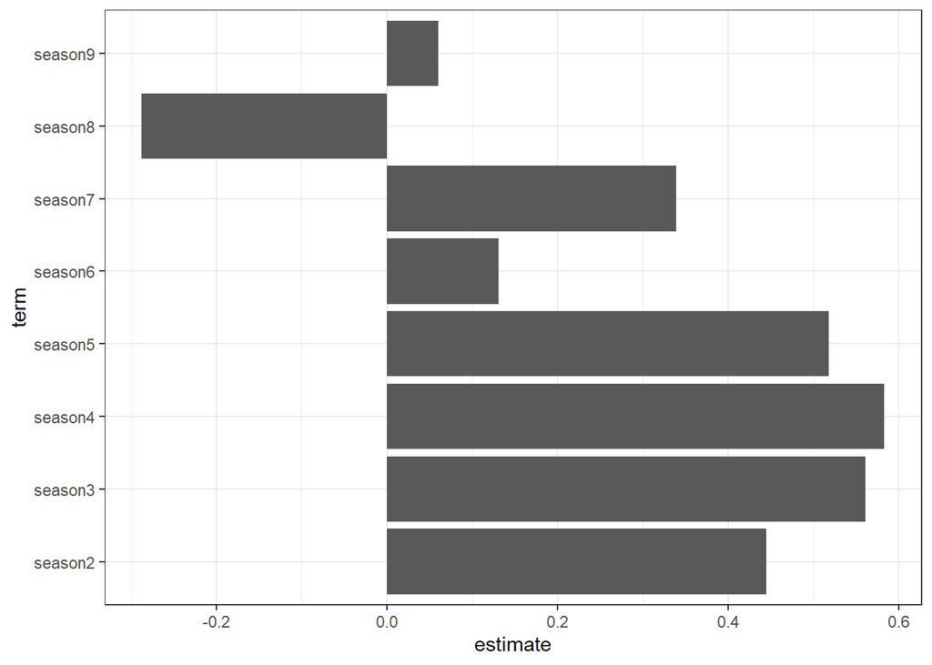

```r
fit_lm |>
  tidy() |>
   filter(str_detect(term, "(Intercept)") == FALSE) |>
  ggplot(aes(x = estimate,
             y = term)) +
  geom_col()
```

Why isn’t there an estimated coefficient for Season 1?

Season 1 is represented by the intercept. The estimate for season n is the numeric difference between season n’s imdb rating and season 1’s imdb rating.

### Part B [25 points]

Using a recipe-based workflow and the training data, fit a LASSO linear regression model with imdb_rating as the response and all remaining variables as predictors. Use a lasso penalty of 0.01.

The recipe should consist of three steps in the following order.

- For the director variable, create an “other” category for all directors who directed 2 percent or fewer of the episodes. step_other() should be used for this.
- step_dummy() to turn all nominal predictors into factors.
- step_normalize() to normalize all the predictors.

```r
fit_glmnet <- linear_reg(penalty = 0.01) |>
  set_engine("glmnet") |>
  set_mode("regression")
```

```r
recipe_office <- recipe(data = theoffice_train,
                      formula = imdb_rating ~ .)

recipe_office <- recipe_office |>
  step_other(director,
             threshold = 0.02,
             other = "other") |>
  step_dummy(all_nominal_predictors()) |>
  step_normalize(all_predictors())
```

```r
recipe_workflow_glm <- workflow()

recipe_workflow_glm <- recipe_workflow_glm |>
  add_model(fit_glmnet) |>
  add_recipe(recipe_office)

recipe_workflow_glm
```

```
## ══ Workflow ════════════════════════════════════════════════════════════════════
## Preprocessor: Recipe
## Model: linear_reg()
##
## ── Preprocessor ────────────────────────────────────────────────────────────────
## 3 Recipe Steps
##
## • step_other()
## • step_dummy()
## • step_normalize()
##
## ── Model ───────────────────────────────────────────────────────────────────────
## Linear Regression Model Specification (regression)
##
## Main Arguments:
##   penalty = 0.01
##
## Computational engine: glmnet
```

```r
fit_glm <- recipe_workflow_glm |>
  fit(theoffice_train)

fit_glm |>
  tidy()
```

```
## # A tibble: 106 × 3
##    term                     estimate penalty
##    <chr>                       <dbl>   <dbl>
##  1 (Intercept)                8.28      0.01
##  2 season_percentage          0         0.01
##  3 episode                    0.0967    0.01
##  4 dialog_share_michael       0.147     0.01
##  5 dialog_share_jim           0.0365    0.01
##  6 dialog_share_pam           0         0.01
##  7 dialog_share_dwight        0.0143    0.01
##  8 dialog_share_jan           0.0425    0.01
##  9 dialog_share_michel        0         0.01
## 10 dialog_share_todd_packer  -0.0272    0.01
## # ℹ 96 more rows
```

In this model, which character’s dialog is estimated to have the highest positive effect on episode rating?

```r
fit_glm |>
  tidy() |>
  filter(str_starts(term, "dialog")) |>
  arrange(desc(estimate))
```

```
## # A tibble: 64 × 3
##    term                       estimate penalty
##    <chr>                         <dbl>   <dbl>
##  1 dialog_share_michael         0.147     0.01
##  2 dialog_share_all             0.104     0.01
##  3 dialog_share_everyone        0.0606    0.01
##  4 dialog_share_david_wallace   0.0576    0.01
##  5 dialog_share_bartender       0.0511    0.01
##  6 dialog_share_stanley         0.0493    0.01
##  7 dialog_share_carol           0.0449    0.01
##  8 dialog_share_jan             0.0425    0.01
##  9 dialog_share_woman           0.0397    0.01
## 10 dialog_share_toby            0.0378    0.01
## # ℹ 54 more rows
```

```r
# Michael
```

Which writer is estimated to have the highest positive effect on episode rating?

```r
fit_glm |>
  tidy() |>
  filter(str_starts(term, "writer")) |>
  arrange(desc(estimate))
```

```
## # A tibble: 16 × 3
##    term                      estimate penalty
##    <chr>                        <dbl>   <dbl>
##  1 writer_greg_daniels        0.0608     0.01
##  2 writer_michael_schur       0.0198     0.01
##  3 writer_daniel_chun         0.0196     0.01
##  4 writer_justin_spitzer      0.0145     0.01
##  5 writer_b_j_novak           0.00866    0.01
##  6 writer_paul_lieberstein    0          0.01
##  7 writer_mindy_kaling        0          0.01
##  8 writer_gene_stupnitsky     0          0.01
##  9 writer_lee_eisenberg       0          0.01
## 10 writer_jennifer_celotta    0          0.01
## 11 writer_brent_forrester     0          0.01
## 12 writer_halsted_sullivan    0          0.01
## 13 writer_warren_lieberstein  0          0.01
## 14 writer_charlie_grandy     -0.0477     0.01
## 15 writer_other              -0.0489     0.01
## 16 writer_aaron_shure        -0.0749     0.01
```

```r
# Greg Daniels
```

Which director is estimated to have the lowest effect on episode rating?

```r
fit_glm |>
  tidy() |>
  filter(str_starts(term, "director")) |>
  arrange(estimate)
```

```
## # A tibble: 15 × 3
##    term                       estimate penalty
##    <chr>                         <dbl>   <dbl>
##  1 director_Randall.Einhorn   -0.0432     0.01
##  2 director_Jennifer.Celotta  -0.0213     0.01
##  3 director_John.Krasinski    -0.0152     0.01
##  4 director_Paul.Lieberstein  -0.00979    0.01
##  5 director_other             -0.00827    0.01
##  6 director_Matt.Sohn         -0.00573    0.01
##  7 director_Ken.Kwapis         0          0.01
##  8 director_Ken.Whittingham    0          0.01
##  9 director_Jeffrey.Blitz      0          0.01
## 10 director_David.Rogers       0          0.01
## 11 director_B.J..Novak         0          0.01
## 12 director_Harold.Ramis       0.00285    0.01
## 13 director_Paul.Feig          0.00512    0.01
## 14 director_Tucker.Gates       0.0243     0.01
## 15 director_Charles.McDougall  0.0274     0.01
```

```r
# Randall Einhorn
```